# Covid Intervention Results

Joey Heffner

16 October, 2020

# Setup

To run this analysis script you’ll have to have the following packages installed (make sure `tidyverse` is updated):

`here`, `tidyverse`, `knitr`, `kableExtra`, `lsr`, `broom.mixed`, `AICcmodavg`, `cowplot`, `ggrepel`

To install these packages simply use the `install.packages()` function and put each package name in as a character.

**Note**: If you’ve already used the `here()` function in another script, you will have to open a new instance of R to ensure the relative pathing works for this script (or manually change the pathing).

# Covid Intervention

The order of this Markdown will follow the order of results in the manuscript which is published in the journal of Personality and Individual Differences at the following [DOI](https://doi.org/10.1016/j.paid.2020.110420).

# Data

The general purpose of this experiment was to determine how effective `threat` and `prosocial` interventions were in increasing preventative behavior related to COVID-19. Below you can see a snippet of the data where the columns refer to:

- `sub`: unique subject identifier
- `intervention`: `threat` intervention or `prosocial` intervention
- `valence`: unpleasant (-) or pleasant (+) rating of the intervention (range -250 to +250)
- `arousal`: low (-) or high (+) arousal rating of the intervention (range -250 to + 250)
- `willingness`: self-report rating of willingness to self-isolate (0 - not at all), (100 - completely)
- `change`: self-report change in willingness to self-isolate after reading intervention (0 - no change), (100 - a lot of change)
- `stay_home`: self-report baseline for self-isolation ("I stayed home; 0 - not at all, 100 - all the time)
- `mean_behavior`: self-report average baseline for preventative behaviors (variety of behaviors, 0- not at all, 100 - all the time)
- `bfi_extraversion`: extraversion personality measure from the BFI-2-S; [Soto & John, 2017](https://www.sciencedirect.com/science/article/abs/pii/S0092656616301325)
- `bfi_neuroticism`: neuroticism personality measure from the BFI-2-S; [Soto & John, 2017](https://www.sciencedirect.com/science/article/abs/pii/S0092656616301325)

Data glimpse

| sub | intervention | valence | arousal | willingness | change | stay_home | mean_behavior | bfi_extraversion | bfi_neuroticism |
| --- | --- | --- | --- | --- | --- | --- | --- | --- | --- |
| 1 | threat | -219 | 233 | 100 | 51 | 100 | 80.0 | 2.666667 | 3.000000 |
| 1 | prosocial | 52 | 203 | 67 | 66 | 100 | 80.0 | 2.666667 | 3.000000 |
| 2 | threat | -217 | 223 | 100 | 0 | 75 | 86.6 | 3.666667 | 3.833333 |
| 2 | prosocial | 179 | 221 | 100 | 49 | 75 | 86.6 | 3.666667 | 3.833333 |
| 3 | threat | -163 | -13 | 71 | 31 | 69 | 85.4 | 3.500000 | 2.500000 |
| 3 | prosocial | -153 | -240 | 59 | 1 | 69 | 85.4 | 3.500000 | 2.500000 |

# Interventions

The two intervention prompts are shown below:

## Threat

“The coronavirus is coming for you. When it does, your healthcare system will be overwhelmed. Your fellow citizens will be turned away at the hospital doors. Exhausted healthcare workers will break down. Millions will die. The only way to prevent this crisis is social distancing today.”

## Prosocial

“Help save our most vulnerable. Together, we can stop the coronavirus. Everyone’s actions count, every single person can help to slow the crisis. We have the tools to solve this problem. Together, by self isolating we can save millions of lives.”

## Questions

The three questions participants were asked after each intervention are shown below:

1. How does this statement make you feel? (`valence` + `arousal`)
2. On a scale from 0 (not at all) to 100 (completely), how willing are you to self-isolate? (`willingness`)
3. On a scale from 0 (no change) to 100 (a lot of change), how much does the previous statement change your willingness to self-isolate? (`change`)

# Pre-figure 1

Stay_Home Descriptive

| avg_stay_home |
| --- |
| 87.31099 |

Difference descriptives

| intervention | avg_diff | sd_diff | N |
| --- | --- | --- | --- |
| prosocial | 6.50 | 15.71 | 955 |
| threat | 6.44 | 15.41 | 955 |

One-sample t-tests comparing `avg_diff` to 0

|  | t | df | p | mu | cohen_d |
| --- | --- | --- | --- | --- | --- |
| threat | 12.92 | 954 | 0.000 | 0 | 0.42 |
| prosocial | 12.79 | 954 | 0.000 | 0 | 0.41 |

# Figure 1a

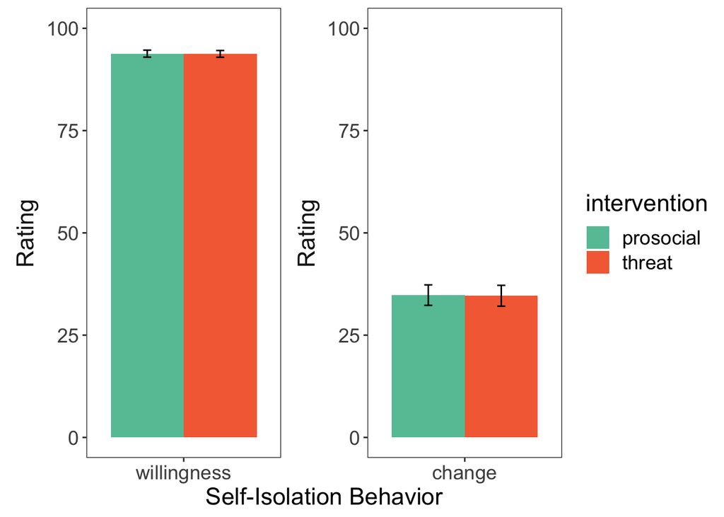

| intervention | question | Mean | SD | N | SE | lwr | upr |
| --- | --- | --- | --- | --- | --- | --- | --- |
| prosocial | willingness | 93.81466 | 13.43047 | 955 | 0.4345998 | 92.96178 | 94.66754 |
| prosocial | change | 34.78639 | 39.30756 | 955 | 1.2719628 | 32.29022 | 37.28256 |
| threat | willingness | 93.75497 | 12.95835 | 955 | 0.4193225 | 92.93207 | 94.57787 |
| threat | change | 34.63037 | 40.14088 | 955 | 1.2989282 | 32.08128 | 37.17945 |

Paired-sample t-tests

|  | t | df | p |
| --- | --- | --- | --- |
| willingness | 0.25 | 954 | 0.806 |
| change | 0.17 | 954 | 0.868 |

```
## [1] -0.06757438
```

```
##
##  Pearson's product-moment correlation
##
## data:  df$willingness[df$intervention == "prosocial"] and df$change[df$intervention == "prosocial"]
## t = -2.0908, df = 953, p-value = 0.03681
## alternative hypothesis: true correlation is not equal to 0
## 95 percent confidence interval:
##  -0.130452658 -0.004154698
## sample estimates:
##         cor
## -0.06757438
```

```
## [1] -0.06729609
```

```
##
##  Pearson's product-moment correlation
##
## data:  df$willingness[df$intervention == "threat"] and df$change[df$intervention == "threat"]
## t = -2.0822, df = 953, p-value = 0.03759
## alternative hypothesis: true correlation is not equal to 0
## 95 percent confidence interval:
##  -0.130177841 -0.003875138
## sample estimates:
##         cor
## -0.06729609
```

# Figure 1b

In Figure 1b, we show the emotional experiences participants report having after reading each intervention. We developed this measurement technique from prior work (Heffner, Son & FeldmanHall, under review) where participants make emotion ratings on a 2D surface with valence and arousal axes. See preprint for more details.

The code chunk will produce a graph (`fig1b_plot`), descriptives for this plot, and t-test comparisons between the interventions on valence and arousal experiences.

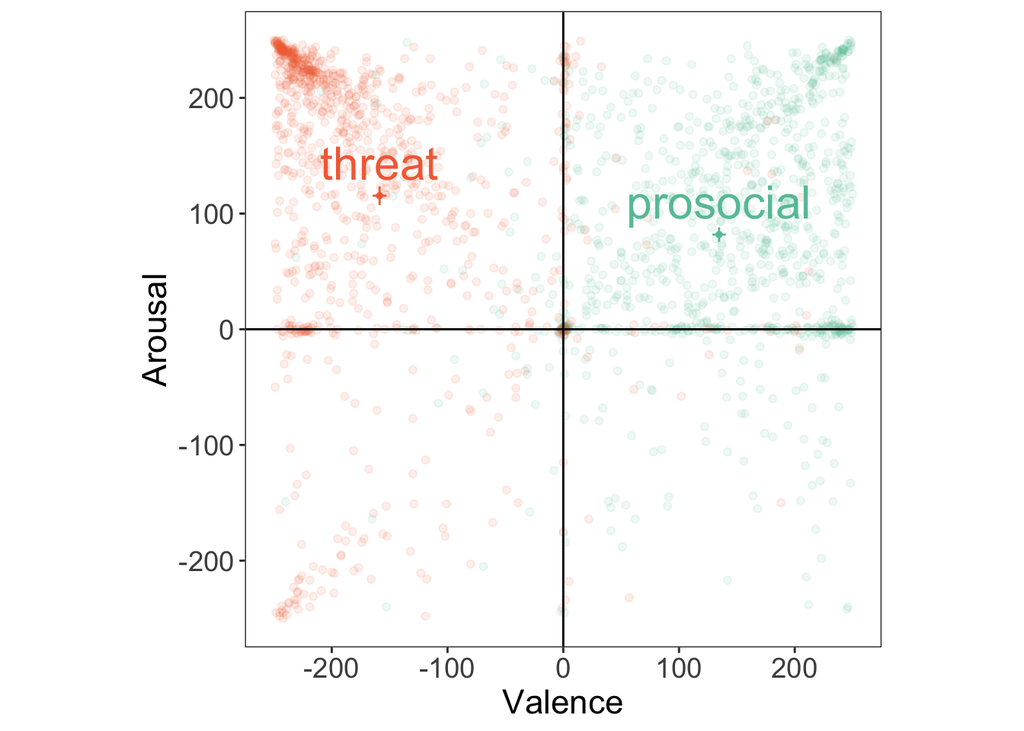

| intervention | meanValence | meanArousal | sdValence | sdArousal | N | seValence | seArousal | ciLowerValence | ciUpperValence | ciLowerArousal | ciUpperArousal |
| --- | --- | --- | --- | --- | --- | --- | --- | --- | --- | --- | --- |
| prosocial | 134.6042 | 81.88168 | 90.95398 | 99.37417 | 955 | 2.943202 | 3.215673 | 128.8283 | 140.3801 | 75.57107 | 88.19228 |
| threat | -158.6702 | 115.45969 | 94.28304 | 126.59892 | 955 | 3.050928 | 4.096645 | -164.6575 | -152.6829 | 107.42021 | 123.49916 |

Paired-sample t-tests

|  | t | df | p | cohen_d |
| --- | --- | --- | --- | --- |
| arousal | 7.90 | 954 | 0.000 | 0.26 |
| valence | -68.50 | 954 | 0.000 | 2.22 |
| abs(valence) | 7.56 | 954 | 0.000 | 0.24 |

# Pre-figure 2

Before Figure 2, we present some analyses examining the relationship between emotional engagement and personality traits (`extraversion` and `neuroticism`) by intervention. Specifically, we conduct linear-mixed effects regressions examining the relationship between `arousal` and `valence` (separately) to `extraversion` and `neuroticism` (separately) by intervention.

## Neuroticism analyses

Arousal ~ Intervention*Neuroticism + (1|sub)

| term | estimate | std.error | df | statistic | p.value | p.label |
| --- | --- | --- | --- | --- | --- | --- |
| (Intercept) | 0.7618572 | 0.0242494 | 953 | 31.417546 | 0.000 | *** |
| interventionprosocial | -0.2215635 | 0.0278811 | 953 | -7.946727 | 0.000 | *** |
| neuroticism_scale | 0.0692859 | 0.0242558 | 953 | 2.856470 | 0.004 | ** |
| interventionprosocial:neuroticism_scale | -0.1012061 | 0.0278884 | 953 | -3.628967 | 0.000 | *** |

Note:  
Intervention reference category is threat

Valence ~ Intervention*Neuroticism + (1|sub)

| term | estimate | std.error | df | statistic | p.value | p.label |
| --- | --- | --- | --- | --- | --- | --- |
| (Intercept) | -0.9125147 | 0.0171536 | 953 | -53.1967388 | 0.000 | *** |
| interventionprosocial | 1.6866255 | 0.0242588 | 953 | 69.5262548 | 0.000 | *** |
| neuroticism_scale | -0.0473768 | 0.0171581 | 953 | -2.7611942 | 0.006 | ** |
| interventionprosocial:neuroticism_scale | -0.0154655 | 0.0242652 | 953 | -0.6373556 | 0.524 | n.s. |

Note:  
Intervention reference category is threat

## Extraversion analyses

Arousal ~ Intervention*Extraversion + (1|sub)

| term | estimate | std.error | df | statistic | p.value | p.label |
| --- | --- | --- | --- | --- | --- | --- |
| (Intercept) | 0.7618572 | 0.0242829 | 953 | 31.3741811 | 0.000 | *** |
| interventionprosocial | -0.2215635 | 0.0279956 | 953 | -7.9142186 | 0.000 | *** |
| extraversion_scale | -0.0141924 | 0.0242893 | 953 | -0.5843085 | 0.559 | n.s. |
| interventionprosocial:extraversion_scale | 0.0643514 | 0.0280030 | 953 | 2.2980229 | 0.022 | * |

Note:  
Intervention reference category is threat

Valence ~ Intervention*Extraversion + (1|sub)

| term | estimate | std.error | df | statistic | p.value | p.label |
| --- | --- | --- | --- | --- | --- | --- |
| (Intercept) | -0.9125147 | 0.0171940 | 953 | -53.071804 | 0.000 | *** |
| interventionprosocial | 1.6866255 | 0.0243159 | 953 | 69.362970 | 0.000 | *** |
| extraversion_scale | 0.0173386 | 0.0171985 | 953 | 1.008147 | 0.314 | n.s. |
| interventionprosocial:extraversion_scale | 0.0396537 | 0.0243223 | 953 | 1.630345 | 0.103 | n.s. |

Note:  
Intervention reference category is threat

# Figure 2

In Figure 2 we show the relationship between emotional experiences and reported willingness to self-isolate after reading the prosocial intervention. The code chunk below will product two graphs (`fig2a_plot`, `fig2b_plot`) which were combined in Illustrator alongside including significance indicators. Additionally, the code will run a linear mixed-effects model predicting willingness to self-isolate as a function of the valence and arousal of each intervention. The significant results are highlighted in red and show that the emotional experience predicts reported willingness to self-isolate after the prosocial intervention.

**Note**: please note that the significance from the simple effects are derived by changing the reference category in the main mixed-effects regression. While the model outputs that are shown here use `threat` as the reference category (meaning the simple effects of `valence` and `arousal` are in reference to `threat`), simply change the reference category to `prosocial` to examine its simple effects.

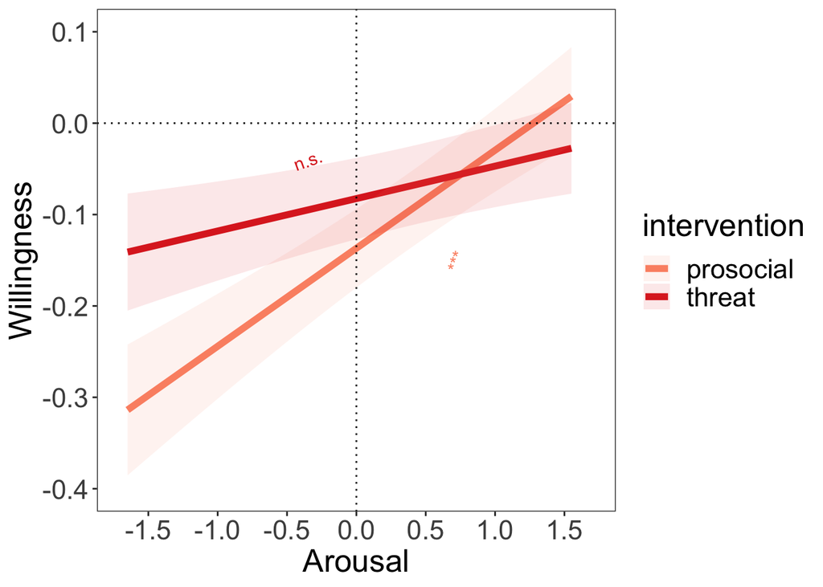

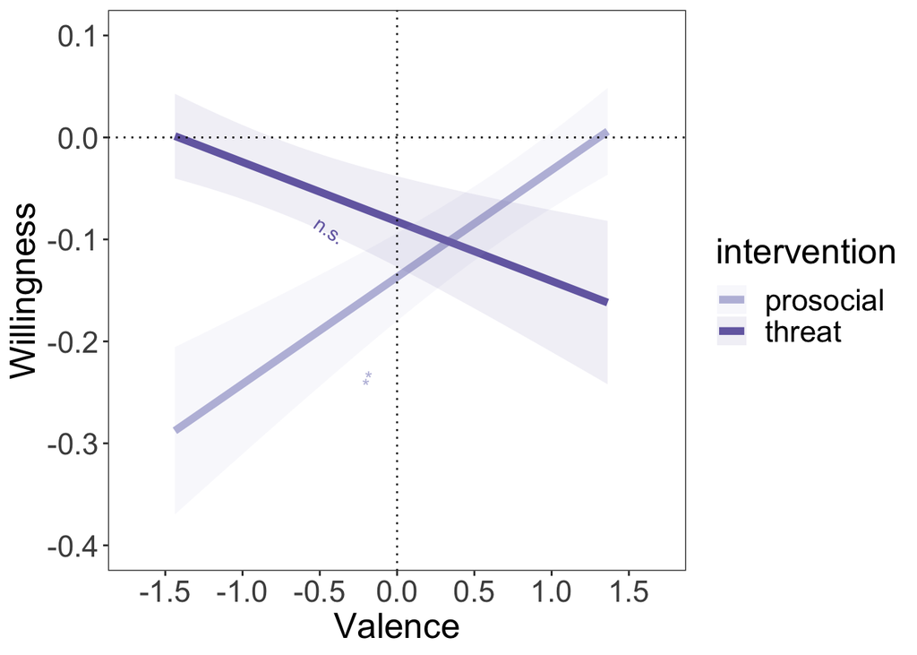

Willingness Model

| term | estimate | std.error | df | statistic | p.value | p.label |
| --- | --- | --- | --- | --- | --- | --- |
| (Intercept) | -0.0825120 | 0.0445083 | 954 | -1.853856 | 0.064 | n.s. |
| interventionprosocial | -0.0543621 | 0.0441356 | 950 | -1.231706 | 0.218 | n.s. |
| valence_scale | -0.0583087 | 0.0331720 | 950 | -1.757765 | 0.079 | n.s. |
| arousal_scale | 0.0354955 | 0.0223658 | 950 | 1.587044 | 0.113 | n.s. |
| interventionprosocial:valence_scale | 0.1631844 | 0.0478014 | 950 | 3.413798 | 0.001 | *** |
| interventionprosocial:arousal_scale | 0.0717621 | 0.0314836 | 950 | 2.279353 | 0.023 | * |

Note:  
Formula: willingness_scale ~ intervention * valence_scale + intervention * arousal_scale + (1 + intervention|sub) Intervention reference category is threat

# Figure 3

In Figure 3 we show the relationship between emotional experiences and reported changes in self-isolation (a different measure from willingness) after reading the prosocial intervention. The code chunk below will product two graphs (`fig3a_plot`, `fig3b_plot`) which were combined in Illustrator alongside including significance indicators. Additionally, the code will run a linear mixed-effects model predicting changes to self-isolate as a function of the valence and arousal of each intervention. The significant results are highlighted in red and show that the emotional experience predicts reported changes in self-isolation after the prosocial intervention.

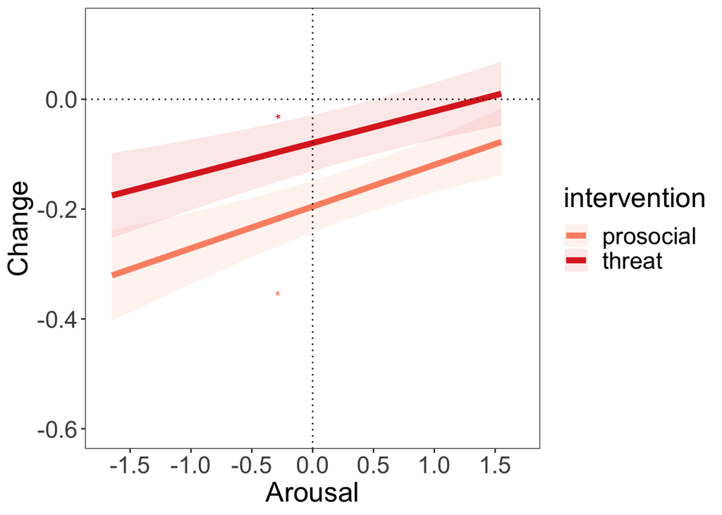

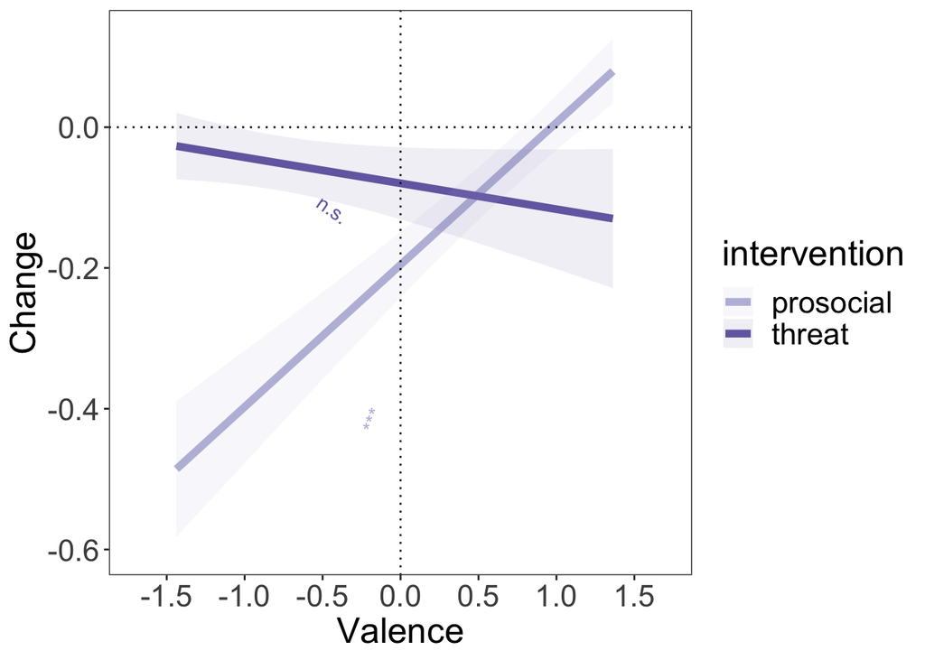

Change Model

| term | estimate | std.error | df | statistic | p.value | p.label |
| --- | --- | --- | --- | --- | --- | --- |
| (Intercept) | -0.0796704 | 0.0512357 | 954 | -1.5549786 | 0.120 | n.s. |
| interventionprosocial | -0.1157335 | 0.0552620 | 950 | -2.0942684 | 0.037 | * |
| valence_scale | -0.0368142 | 0.0420870 | 950 | -0.8747167 | 0.382 | n.s. |
| arousal_scale | 0.0579015 | 0.0281240 | 950 | 2.0587899 | 0.040 | * |
| interventionprosocial:valence_scale | 0.2387380 | 0.0592194 | 950 | 4.0314162 | 0.000 | *** |
| interventionprosocial:arousal_scale | 0.0180880 | 0.0391716 | 950 | 0.4617620 | 0.644 | n.s. |

Note:  
Formula: change_scale ~ intervention*valence_scale + intervention*arousal_scale + (1 + intervention|sub) Intervention reference category is threat

# Session Info

Because packages change and can break scripts at later timepoints I have included a snapshot of my session information for full reproducibility.

[session information not shown]

# Appendix

If you are interested in seeing the actual code for producing all these analyses and figures it is displayed below. Thank you!

```r
# Knitr options
knitr::opts_chunk$set(echo = FALSE, warnings = FALSE, message = FALSE)

# Save plots or not
save_plots <- FALSE  # if you want to generate new plots make TRUE

# Libraries
library(here)         # relative paths
library(tidyverse)    # tidy functions
library(knitr)        # knit functions
library(kableExtra)   # extra markdown functions
library(lsr)          # cohenD()
library(broom.mixed)  # tidy()
library(AICcmodavg)   # predictSE()
library(cowplot)      # plot_grid()
library(ggrepel)      # geom_text_repel
# Specify relative pathing
dir_analysis <- here() # should be where analysis script is stored
dir_parent <- dir_analysis %>% str_remove("/Analysis")
dir_data <- paste0(dir_parent, "/Data")
dir_graphs <- paste0(dir_parent, "/Graphs")

# Load data
df <- read_csv(paste0(dir_data, "/covid_intervention.csv"))

# Glimpse of data
head(df) %>%
  kable(caption = "Data glimpse") %>%
  kable_styling(bootstrap_options = c("striped", "hover", "condensed", "responsive"))
## Average stay_home behavior
stay_home <- df %>%
  select(sub, stay_home) %>%
  unique() %>%
  summarise(avg_stay_home = mean(stay_home))

## Skew
skew <- e1071::skewness(df %>% select(sub, stay_home) %>% unique() %>% .$stay_home)

stay_home %>%
  kable(caption = "Stay_Home Descriptive") %>%
  kable_styling(bootstrap_options = c("striped", "hover", "condensed", "responsive"))

## Difference measures
difference <- df %>%
  mutate(delta = willingness - stay_home,
         delta2 = willingness - mean_behavior)

# Difference descriptives
difference_avg <- difference %>%
  group_by(intervention) %>%
  summarise(avg_diff = round(mean(delta), 2), sd_diff = round(sd(delta), 2), N = n())

difference_avg %>%
  kable(caption = "Difference descriptives") %>%
  kable_styling(bootstrap_options = c("striped", "hover", "condensed", "responsive"))

# Difference statistics
diff_t1a <- t.test(difference %>% filter(intervention == "threat") %>% .$delta, mu = 0)
d_t1a <- cohensD(difference %>% filter(intervention == "threat") %>% .$delta, mu = 0)

# Manually generate tables for easier viewing
t1_table <- data.frame(row.names = "threat",
                       t = round(diff_t1a$statistic, 2),
                       df = diff_t1a$parameter,
                       p = format(round(diff_t1a$p.value, 3), nsmall = 3),
                       mu = diff_t1a$null.value,
                       cohen_d = round(d_t1a, 2))

diff_t2a <- t.test(difference %>% filter(intervention == "prosocial") %>% .$delta, mu = 0)
d_t2a <- cohensD(difference %>% filter(intervention == "prosocial") %>% .$delta, mu = 0)

t2_table <- data.frame(row.names = "prosocial",
                       t = round(diff_t2a$statistic, 2),
                       df = diff_t2a$parameter,
                       p = format(round(diff_t2a$p.value, 3), nsmall = 3),
                       mu = diff_t2a$null.value,
                       cohen_d = round(d_t2a, 2))

t_tables <- rbind(t1_table, t2_table)
t_tables %>%
  kable(caption = "One-sample t-tests comparing `avg_diff` to 0") %>%
kable_styling(bootstrap_options = c("striped", "hover", "condensed", "responsive"))

## Same analysis with `mean_behavior` difference to 0
diff_t1b <- t.test(difference %>% filter(intervention == "threat") %>% .$delta2, mu = 0)
d_t1b <- cohensD(difference %>% filter(intervention == "threat") %>% .$delta2, mu = 0)

diff_t2b <- t.test(difference %>% filter(intervention == "prosocial") %>% .$delta2, mu = 0)
d_t2b <- cohensD(difference %>% filter(intervention == "prosocial") %>% .$delta2, mu = 0)
## Figure 1a - Overall intervention
fig1a_data <- df %>%
  select(sub, intervention, willingness, change) %>%
  pivot_longer(cols = c(willingness, change), names_to = "question", values_to = "value") %>%
  mutate(question = fct_relevel(question, "willingness", "change")) %>%
  group_by(intervention, question) %>%
  summarise(Mean = mean(value), SD = sd(value), N = n(), SE = SD/sqrt(N)) %>%
  mutate(lwr = Mean - qt(1 - (0.05 / 2), N - 1) * SE,
         upr = Mean + qt(1 - (0.05 / 2), N - 1) * SE)

# Aesthetics
intervention_colors <- c("#66c2a5", "#f46d43") # prosocial, threat

fig1a_plot <- ggplot(fig1a_data, aes(x = question, y = Mean, fill = intervention)) +
  geom_bar(stat = "identity", position = position_dodge(.9)) +
  geom_errorbar(aes(ymin = lwr, ymax = upr), position = position_dodge(.9), width = .1) +
  scale_fill_manual(values = intervention_colors) +
  scale_y_continuous(name = NULL, limits = c(0, 100)) +
  xlab("Self-Isolation Behavior") +
  facet_wrap(~question, scales = "free",
             strip.position = "left",
             labeller = as_labeller(c(willingness = "Rating", change = "Rating"))) +
  theme_bw() +
  theme(axis.text = element_text(size = rel(1.25)),
        axis.title = element_text(size = rel(1.5)),
        legend.text = element_text(size = rel(1.25)),
        legend.title = element_text(size = rel(1.5)),
        panel.grid.major = element_blank(),
        panel.grid.minor = element_blank(),
        strip.text = element_text(size = rel(1.5)),
        strip.background = element_blank(),
        strip.placement = "outside")
fig1a_plot

if (save_plots == TRUE) {
  ggsave(filename = paste0(dir_graphs, "/fig1a.pdf"), plot = fig1a_plot, width = 6, height = 6)
}

# Figure 1a descriptives
fig1a_data %>%
  kable() %>%
  kable_styling(bootstrap_options = c("striped", "hover", "condensed", "responsive"))

# Figure 1a statistics
t1_test <- t.test(willingness ~ intervention, paired = TRUE, data = df) # cleaner paired t-test code
# t.test(df$willingness[df$intervention == "threat"], df$willingness[df$intervention == "prosocial"], paired = TRUE) # same results
t1_table <- data.frame(row.names = "willingness",
                       t = round(t1_test$statistic, 2),
                       df = t1_test$parameter,
                       p = format(round(t1_test$p.value, 3), nsmall = 3))

t2_test <- t.test(change ~ intervention, paired = TRUE, data = df)
t2_table <- data.frame(row.names = "change",
                       t = round(t2_test$statistic, 2),
                       df = t2_test$parameter,
                       p = format(round(t2_test$p.value, 3), nsmall = 3))
```

```r
t_tables <- rbind(t1_table, t2_table)
t_tables %>%
  kable(caption = "Paired-sample t-tests") %>%
  kable_styling(bootstrap_options = c("striped", "hover", "condensed", "responsive"))

# Correlation
cor(df$willingness[df$intervention == "prosocial"],
    df$change[df$intervention == "prosocial"])
cor.test(df$willingness[df$intervention == "prosocial"],
    df$change[df$intervention == "prosocial"])

cor(df$willingness[df$intervention == "threat"],
    df$change[df$intervention == "threat"])
cor.test(df$willingness[df$intervention == "threat"],
    df$change[df$intervention == "threat"])

## Figure 1b - Emotional experiences
# Average emotions
fig1b_data <- df %>%
  group_by(intervention) %>%
  dplyr::summarise(meanValence = mean(valence), meanArousal = mean(arousal),
                   sdValence = sd(valence), sdArousal = sd(arousal), N = n(),
                   seValence = sdValence / sqrt(N), seArousal = sdArousal / sqrt(N)) %>%
  mutate(ciLowerValence = meanValence - qt(1 - (0.05 / 2), N - 1) * seValence,
         ciUpperValence = meanValence + qt(1 - (0.05 / 2), N - 1) * seValence,
         ciLowerArousal = meanArousal - qt(1 - (0.05 / 2), N - 1) * seArousal,
         ciUpperArousal = meanArousal + qt(1 - (0.05 / 2), N - 1) * seArousal)

fig1b_plot <- ggplot(df, aes(x = valence, y = arousal, color = intervention)) + geom_point(alpha = .1) + # all data points
  geom_point(data = fig1b_data, aes(x = meanValence, y = meanArousal, color = intervention), size = 1) + # averages
  geom_errorbar(data = fig1b_data, aes(x = meanValence, y = meanArousal, ymin = ciLowerArousal, ymax = ciUpperArousal), width = 0) + # CIs
  geom_errorbarh(data = fig1b_data, aes(x = NULL, y = meanArousal, xmin = ciLowerValence, xmax = ciUpperValence), height = 0) + # CIs
  geom_text_repel(data = fig1b_data, aes(x = meanValence, y = meanArousal, color = intervention, label = intervention),
                  segment.colour = NA, point.padding = .3, show.legend = FALSE, size = 8, nudge_y = 1, direction = "y") +
  geom_hline(yintercept = 0) +
  geom_vline(xintercept = 0) +
  coord_fixed() +
  scale_color_manual(values = intervention_colors) +
  scale_y_continuous(name = "Arousal", limits = c(-250, 250), breaks = seq(-200, 200, by = 100)) +
  scale_x_continuous(name = "Valence", limits = c(-250, 250), breaks = seq(-200, 200, by = 100)) +
  theme_bw() +
  theme(axis.text = element_text(size = rel(1.25)),
        axis.title = element_text(size = rel(1.5)),
        legend.text = element_text(size = rel(1.25)),
        legend.title = element_text(size = rel(1.5)),
        legend.position = "none",
        panel.grid.major = element_blank(),
        panel.grid.minor = element_blank())
fig1b_plot

if (save_plots == TRUE) {
  ggsave(filename = paste0(dir_graphs, "/fig1b.pdf"), plot = fig1b_plot, width = 6, height = 6)
}

# Figure 1b descriptives
fig1b_data %>%
  kable() %>%
  kable_styling(bootstrap_options = c("striped", "hover", "condensed", "responsive"))

# Figure 1b statistics
t1_test <- t.test(df$arousal[df$intervention == "threat"], df$arousal[df$intervention == "prosocial"], paired = TRUE, data = df)
t1_d <- cohensD(x = df$arousal[df$intervention == "threat"], y = df$arousal[df$intervention == "prosocial"], method = "paired") # less clean but works with cohenD function
t1_table <- data.frame(row.names = "arousal",
                       t = round(t1_test$statistic, 2),
                       df = t1_test$parameter,
                       p = format(round(t1_test$p.value, 3), nsmall = 3),
                       cohen_d = round(t1_d, 2))

t2_test <- t.test(df$valence[df$intervention == "threat"], df$valence[df$intervention == "prosocial"], paired = TRUE, data = df)
t2_d <- cohensD(x = df$valence[df$intervention == "threat"], y = df$valence[df$intervention == "prosocial"], method = "paired")
t2_table <- data.frame(row.names = "valence",
                       t = round(t2_test$statistic, 2),
                       df = t2_test$parameter,
                       p = format(round(t2_test$p.value, 3), nsmall = 3),
                       cohen_d = round(t2_d, 2))

t3_test <- t.test(abs(df$valence[df$intervention == "threat"]), abs(df$valence[df$intervention == "prosocial"]), paired = TRUE, data = df)
t3_d <- cohensD(x = abs(df$valence[df$intervention == "threat"]), y = abs(df$valence[df$intervention == "prosocial"]), method = "paired")
t3_table <- data.frame(row.names = "abs(valence)",
                       t = round(t3_test$statistic, 2),
                       df = t3_test$parameter,
                       p = format(round(t3_test$p.value, 3), nsmall = 3),
                       cohen_d = round(t3_d, 2))

t_tables <- rbind(t1_table, t2_table, t3_table)
t_tables %>%
  kable(caption = "Paired-sample t-tests") %>%
  kable_styling(bootstrap_options = c("striped", "hover", "condensed", "responsive"))
# Figure 2 data used for pre-figure 2 and figure 2
fig2_data <- df %>%
  mutate(willingness_scale = as.numeric(scale(willingness)),
         change_scale = as.numeric(scale(change)),
         valence_scale = as.numeric(scale(valence, center = F)),               # scale but not mean-center (0 = neutral)
         arousal_scale = as.numeric(scale(arousal, center = F)),               # scale but not mean-center (0 = neutral)
         extraversion_scale = as.numeric(scale(bfi_extraversion, center = T)), # scale and mean-center (0 = average)
         neuroticism_scale = as.numeric(scale(bfi_neuroticism, center = T)),   # scale and mean-center (0 = average)
         intervention = fct_relevel(intervention, "threat", "prosocial"),      # reference point threat
         intervention_opp = fct_relevel(intervention, "prosocial", "threat")) # reference point prosocial

## Neuroticism analysis
# Arousal ~ intervention*neuroticism
neuro_a <- nlme::lme(arousal_scale ~ intervention*neuroticism_scale, random = ~ 1| sub,
                data = fig2_data)

# Simple effect of prosocial
neuro_a_s <- nlme::lme(arousal_scale ~ intervention_opp*neuroticism_scale, random = ~ 1| sub,
                data = fig2_data)
```

```r
# Display arousal model
broom::tidy(neuro_a, effect = "fixed") %>%
  mutate(
    p.value = format(round(p.value, digits=3), nsmall = 3),
    p.label = case_when(p.value <= .001 ~ "***",
                        p.value <= .01 ~ "**",
                        p.value <= .05 ~ "*",
                        p.value > .05 ~ "n.s."),
    p.value = cell_spec(p.value,
                        "html",
                        color = "white",
                        background = if_else(p.value < 0.05, "red", "black")),
    p.label = cell_spec(p.label,
                        "html",
                        color = "white",
                        background = if_else(p.label != "n.s.", "red", "black"))
  ) %>%
  kable(format = "html",
        caption = "Arousal ~ Intervention*Neuroticism + (1|sub)",
        escape = FALSE) %>% # escape = FALSE critical to avoid escaping special characters in the HTML
  kable_styling(bootstrap_options = c("striped", "hover", "condensed", "responsive")) %>%
  footnote(general = "Intervention reference category is threat")

# Valence ~ intervention*extraversion
neuro_v <- nlme::lme(valence_scale ~ intervention*neuroticism_scale, random = ~ 1| sub,
                data = fig2_data)

# Simple effect of prosocial
neuro_v_s <- nlme::lme(valence_scale ~ intervention_opp*neuroticism_scale, random = ~ 1| sub,
                data = fig2_data)

# Display valence model
broom::tidy(neuro_v, effect = "fixed") %>%
  mutate(
    p.value = format(round(p.value, digits=3), nsmall = 3),
    p.label = case_when(p.value <= .001 ~ "***",
                        p.value <= .01 ~ "**",
                        p.value <= .05 ~ "*",
                        p.value > .05 ~ "n.s."),
    p.value = cell_spec(p.value,
                        "html",
                        color = "white",
                        background = if_else(p.value < 0.05, "red", "black")),
    p.label = cell_spec(p.label,
                        "html",
                        color = "white",
                        background = if_else(p.label != "n.s.", "red", "black"))
  ) %>%
  kable(format = "html",
        caption = "Valence ~ Intervention*Neuroticism + (1|sub)",
        escape = FALSE) %>% # escape = FALSE critical to avoid escaping special characters in the HTML
  kable_styling(bootstrap_options = c("striped", "hover", "condensed", "responsive")) %>%
  footnote(general = "Intervention reference category is threat")
## Extraversion analysis
# Arousal ~ intervention*extraversion
extra_a <- nlme::lme(arousal_scale ~ intervention*extraversion_scale, random = ~ 1| sub,
                data = fig2_data)

# Simple effect of prosocial
extra_a_s <- nlme::lme(arousal_scale ~ intervention_opp*extraversion_scale, random = ~ 1| sub,
                data = fig2_data)

# Display arousal model
broom::tidy(extra_a, effect = "fixed") %>%
  mutate(
    p.value = format(round(p.value, digits=3), nsmall = 3),
    p.label = case_when(p.value <= .001 ~ "***",
                        p.value <= .01 ~ "**",
                        p.value <= .05 ~ "*",
                        p.value > .05 ~ "n.s."),
    p.value = cell_spec(p.value,
                        "html",
                        color = "white",
                        background = if_else(p.value < 0.05, "red", "black")),
    p.label = cell_spec(p.label,
                        "html",
                        color = "white",
                        background = if_else(p.label != "n.s.", "red", "black"))
  ) %>%
  kable(format = "html",
        caption = "Arousal ~ Intervention*Extraversion + (1|sub)",
        escape = FALSE) %>% # escape = FALSE critical to avoid escaping special characters in the HTML
  kable_styling(bootstrap_options = c("striped", "hover", "condensed", "responsive")) %>%
  footnote(general = "Intervention reference category is threat")

# Valence ~ intervention*extraversion
extra_v <- nlme::lme(valence_scale ~ intervention*extraversion_scale, random = ~ 1| sub,
                data = fig2_data)

# Simple effect of prosocial
extra_v_s <- nlme::lme(valence_scale ~ intervention_opp*extraversion_scale, random = ~ 1| sub,
                data = fig2_data)

# Display valence model
broom::tidy(extra_v, effect = "fixed") %>%
  mutate(
    p.value = format(round(p.value, digits=3), nsmall = 3),
    p.label = case_when(p.value <= .001 ~ "***",
                        p.value <= .01 ~ "**",
                        p.value <= .05 ~ "*",
                        p.value > .05 ~ "n.s."),
    p.value = cell_spec(p.value,
                        "html",
                        color = "white",
                        background = if_else(p.value < 0.05, "red", "black")),
    p.label = cell_spec(p.label,
                        "html",
                        color = "white",
                        background = if_else(p.label != "n.s.", "red", "black"))
  ) %>%
  kable(format = "html",
        caption = "Valence ~ Intervention*Extraversion + (1|sub)",
        escape = FALSE) %>% # escape = FALSE critical to avoid escaping special characters in the HTML
  kable_styling(bootstrap_options = c("striped", "hover", "condensed", "responsive")) %>%
  footnote(general = "Intervention reference category is threat")
## Figure 2 plot
fig2_theme <- theme_bw() +
  theme(panel.grid.major = element_blank(),
        panel.grid.minor = element_blank(),
        axis.text = element_text(size = rel(1.5)),
        axis.title = element_text(size = rel(1.75)),
        legend.text = element_text(size = rel(1.5)),
        legend.title = element_text(size = rel(1.75)))

range_valence <- range(fig2_data$valence_scale) # fig2_data already defined previously
range_arousal <- range(fig2_data$arousal_scale)
xRange1 <- seq(range_valence[1], range_valence[2], by = .1)
xRange2 <- seq(range_arousal[1], range_arousal[2], by = .1)
xRange3 <- c("prosocial", "threat")

v_pred <- with(fig2_data, expand.grid(valence_scale = xRange1, arousal_scale = 0, intervention = xRange3))
a_pred <- with(fig2_data, expand.grid(valence_scale = 0, arousal_scale = xRange2, intervention = xRange3))
```

```r
# Mixed-effect model (summary printed later)
m_fig2 <- nlme::lme(willingness_scale ~ intervention*valence_scale + intervention*arousal_scale, random = ~ 1 + intervention| sub,
                data = fig2_data)
# Draw graphs
v_results <- AICcmodavg::predictSE(m_fig2, newdata = v_pred)
a_results <- AICcmodavg::predictSE(m_fig2, newdata = a_pred)

v_pred$fit <- v_results$fit
v_pred$se <- v_results$se.fit
a_pred$fit <- a_results$fit
a_pred$se <- a_results$se.fit

arousal_colors <- c("#fc9272", "#de2d26")
valence_colors <- c("#bcbddc", "#756bb1")

# Simple effects
m_fig2_s <- nlme::lme(willingness_scale ~ intervention_opp*valence_scale + intervention_opp*arousal_scale,
                 random = ~ 1 + intervention_opp| sub, data = fig2_data)

fig2a_plot <- ggplot() +
  # Arousal
  geom_line(data = a_pred, aes(x = arousal_scale, y = fit, color = intervention), size = 2) +
  geom_ribbon(data = a_pred, aes(x = arousal_scale, ymax = fit + se, ymin = fit - se, fill = intervention), alpha = .1) +
  scale_x_continuous(name = "Arousal", limits = c(-1.7, 1.7), breaks = c(-1.5, -1.0, -0.5, 0, 0.5, 1.0, 1.5)) +
  scale_y_continuous(name = "Willingness", limits = c(-.4, .1), breaks = c(-0.4, -0.3, -0.2, -0.1, 0, 0.1)) +
  scale_color_manual(values = arousal_colors) +
  scale_fill_manual(values = arousal_colors) +
  geom_hline(yintercept = 0, lty = 3) +
  geom_vline(xintercept = 0, lty = 3) +
  # Significance
  annotate(geom = "text", label = "n.s.", x = -.25, y = -.035, hjust = 1, color = arousal_colors[2], angle = 20) + # threat
  annotate(geom = "text", label = "***", x = .75, y = -.14, hjust = 1, color = arousal_colors[1], angle = 70) + # prosocial
  fig2_theme
fig2a_plot

if (save_plots == TRUE) {
  ggsave(filename = paste0(dir_graphs, "/fig2a.pdf"), plot = fig2a_plot, width = 8, height = 6)
}

fig2b_plot <- ggplot() +
  # Valence
  geom_line(data = v_pred, aes(x = valence_scale, y = fit, color = intervention), size = 2) +
  geom_ribbon(data = v_pred, aes(x = valence_scale, ymax = fit + se, ymin = fit - se, fill = intervention), alpha = .1) +
  scale_x_continuous(name = "Valence", limits = c(-1.7, 1.7), breaks = c(-1.5, -1.0, -0.5, 0, 0.5, 1.0, 1.5)) +
  scale_y_continuous(name = "Willingness", limits = c(-.4, .1), breaks = c(-0.4, -0.3, -0.2, -0.1, 0, 0.1)) +
  scale_color_manual(values = valence_colors) +
  scale_fill_manual(values = valence_colors) +
  geom_hline(yintercept = 0, lty = 3) +
  geom_vline(xintercept = 0, lty = 3) +
  # Significance
  annotate(geom = "text", label = "n.s.", x = -.35, y = -.1, hjust = 1, color = valence_colors[2], angle = -35) + # threat
  annotate(geom = "text", label = "**", x = -.15, y = -.23, hjust = 1, color = valence_colors[1], angle = 70) + # prosocial
  fig2_theme
fig2b_plot

if (save_plots == TRUE) {
  ggsave(filename = paste0(dir_graphs, "/fig2b.pdf"), plot = fig2b_plot, width = 8, height = 6)
}

# Willngness model
broom.mixed::tidy(m_fig2, effect = "fixed") %>%
  mutate(
    p.value = format(round(p.value, digits=3), nsmall = 3),
    p.label = case_when(p.value <= .001 ~ "***",
                        p.value <= .01 ~ "**",
                        p.value <= .05 ~ "*",
                        p.value > .05 ~ "n.s."),
    p.value = cell_spec(p.value,
                        "html",
                        color = "white",
                        background = if_else(p.value < 0.05, "red", "black")),
    p.label = cell_spec(p.label,
                        "html",
                        color = "white",
                        background = if_else(p.label != "n.s.", "red", "black"))
  ) %>%
  kable(format = "html",
        caption = "Willingness Model",
        escape = FALSE) %>% # escape = FALSE critical to avoid escaping special characters in the HTML
  kable_styling(bootstrap_options = c("striped", "hover", "condensed", "responsive")) %>%
  footnote(general = "Formula: willingness_scale ~ intervention * valence_scale + intervention * arousal_scale + (1 + intervention|sub)\n Intervention reference category is threat")
# Same dataframe as in Fig 2

# Mixed-effect model (summary printed later)
m_fig3 <- nlme::lme(change_scale ~ intervention*valence_scale + intervention*arousal_scale, random = ~ 1 + intervention| sub,
                data = fig2_data)

v_results <- AICcmodavg::predictSE(m_fig3, newdata = v_pred)
a_results <- AICcmodavg::predictSE(m_fig3, newdata = a_pred)

v_pred$fit <- v_results$fit
v_pred$se <- v_results$se.fit
a_pred$fit <- a_results$fit
a_pred$se <- a_results$se.fit

# Simple effects
m_fig3_s <- nlme::lme(change_scale ~ intervention_opp*valence_scale + intervention_opp*arousal_scale,
                 random = ~ 1 + intervention_opp| sub, data = fig2_data)

fig3a_plot <- ggplot() +
  # Arousal
  geom_line(data = a_pred, aes(x = arousal_scale, y = fit, color = intervention), size = 2) +
  geom_ribbon(data = a_pred, aes(x = arousal_scale, ymax = fit + se, ymin = fit - se, fill = intervention), alpha = .1) +
  scale_x_continuous(name = "Arousal", limits = c(-1.7, 1.7), breaks = c(-1.5, -1.0, -0.5, 0, 0.5, 1.0, 1.5)) +
  scale_y_continuous(name = "Change", limits = c(-.6, .13), breaks = c(-0.6, -0.4, -0.2, 0.0)) +
  scale_color_manual(values = arousal_colors) +
  scale_fill_manual(values = arousal_colors) +
  geom_hline(yintercept = 0, lty = 3) +
  geom_vline(xintercept = 0, lty = 3) +
  # Significance
  annotate(geom = "text", label = "*", x = -.25, y = -.035, hjust = 1, color = arousal_colors[2], angle = 20) + # threat
  annotate(geom = "text", label = "*", x = -.25, y = -.35, hjust = 1, color = arousal_colors[1], angle = 70) + # prosocial
  fig2_theme
fig3a_plot

if (save_plots == TRUE) {
  ggsave(filename = paste0(dir_graphs, "/fig3a.pdf"), plot = fig3a_plot, width = 8, height = 6)
}

fig3b_plot <- ggplot() +
  # Valence
  geom_line(data = v_pred, aes(x = valence_scale, y = fit, color = intervention), size = 2) +
  geom_ribbon(data = v_pred, aes(x = valence_scale, ymax = fit + se, ymin = fit - se, fill = intervention), alpha = .1) +
  scale_x_continuous(name = "Valence", limits = c(-1.7, 1.7), breaks = c(-1.5, -1.0, -0.5, 0, 0.5, 1.0, 1.5)) +
  scale_y_continuous(name = "Change", limits = c(-.6, .13), breaks = c(-0.6, -0.4, -0.2, 0.0)) +
  scale_color_manual(values = valence_colors) +
  scale_fill_manual(values = valence_colors) +
  geom_hline(yintercept = 0, lty = 3) +
  geom_vline(xintercept = 0, lty = 3) +
  # Significance
  annotate(geom = "text", label = "n.s.", x = -.35, y = -.13, hjust = 1, color = valence_colors[2], angle = -35) + # threat
  annotate(geom = "text", label = "***", x = -.15, y = -.4, hjust = 1, color = valence_colors[1], angle = 70) + # prosocial
  fig2_theme
fig3b_plot
```

```r
if (save_plots == TRUE) {
  ggsave(filename = paste0(dir_graphs, "/fig3b.pdf"), plot = fig3b_plot, width = 8, height = 6)
}

# Change model
broom.mixed::tidy(m_fig3, effect = "fixed") %>%
  mutate(
    p.value = format(round(p.value, digits=3), nsmall = 3),
    p.label = case_when(p.value <= .001 ~ "***",
                        p.value <= .01 ~ "**",
                        p.value <= .05 ~ "*",
                        p.value > .05 ~ "n.s."),
    p.value = cell_spec(p.value,
                        "html",
                        color = "white",
                        background = if_else(p.value < 0.05, "red", "black")),
    p.label = cell_spec(p.label,
                        "html",
                        color = "white",
                        background = if_else(p.label != "n.s.", "red", "black"))
  ) %>%
  kable(format = "html",
        caption = "Change Model",
        escape = FALSE) %>% # escape = FALSE critical to avoid escaping special characters in the HTML
  kable_styling(bootstrap_options = c("striped", "hover", "condensed", "responsive")) %>%
  footnote(general = "Formula: change_scale ~ intervention*valence_scale + intervention*arousal_scale + (1 + intervention|sub)\n Intervention reference category is threat")
sessionInfo()
```